# Lattice

Vamos a comenzar a trabajar con el paquete **lattice**. Como siempre, vamos a cargar el dataset en una variable. Vamos a indicar que los *strings* no los tome como factores (de esa forma los nombres de los coches no son considerados factores). Por otra parte, vamos a generar una variable categórica (no todas/cualquiera -que sería sin la sentencia *stringAsFactor*, sino la que nosotros decidimos) que en este caso será *cylinders*. Finalmente, cargamos la librería en caso de que no esté en uso aún:

```r
auto <-read.csv("/Users/Ariel/Library/Mobile Documents/com~apple~CloudDocs/AADD/DataScience-con-RStudio/Datos/tema2/auto-mpg.csv", stringsAsFactors = F)
auto$cylinders = factor(auto$cylinders,
                        levels = c(3,4,5,6,8),
                        labels = c ("3C", "4C", "5C", "6C", "8C"))
library(lattice)
```

#### Boxplot

Cambia ligeramente la sintaxis de generación del gráfico, en tanto que el resto de indicaciones sobre parámetros gráficos sigue siendo bastante parecida (títulos, leyendas, etc.).

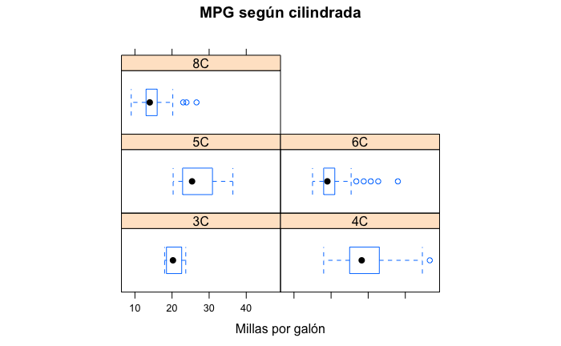

```r
bwplot (~auto$mpg | auto$cylinders,
        main = "MPG según cilindrada",
        xlab = "Millas por galón",
        layout = c(2,3), aspect = 0.4)
```

#### Scatterplot

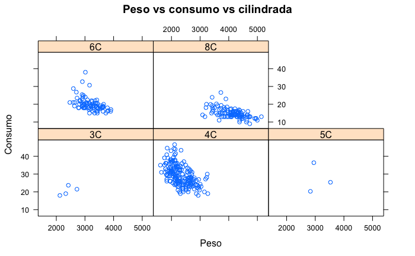

```r
xyplot(mpg~weight | cylinders, data = auto,
       main = "Peso vs consumo vs cilindrada",
       xlab = "Peso",
       ylab = "Consumo")
```

Como vemos, de la sintaxis podemos indicar algunos elementos:

- El paquete **lattice** está especializado en facilitar la segmentación de los gráficos.
- Siempre se coloca al empezar el tipo de gráfico a representar.
- Luego viene la variable (para gráficos de una sola variable como una boxplot) y/o fórmula (cuando hay más de una variable). El símbolo ~ separa ambas variables (y~x).
- Luego agregamos una barra vertical y la variable que usaremos para segmentar el gráfico.
- Para evitar indicar tantas veces el *$posición* podemos hacer uso del parámetro *data*.
- Finalmente, agregamos el resto de leyendas, etc.

Como apuntes finales: * La distribución de los gráficos en filas y columnas se hace con el parámetro **layout** y la relación de aspecto se hace con **aspect**. * Los colores no se modifican de a uno, sino que se modifican los esquemas de color y se utiliza la función **trellis.par.set (theme = (tema))